# Assignment 7

**CS283 Computer Vision, Harvard University, Fall 2019**

**Due Wednesday, Oct. 30, at 5:00pm**

Name: *Natalia Pacheco-Tallaj*

The purpose of this homework is to reinforce the topics of radiometry, reflectance, and photometric stereo. Forsyth and Ponce's chapter on Radiometry will be helpful for this assignment.

As always, your submission must follow the Submission Guidelines and take the form of an HTML version of the notebook (`.html`), and a ZIP containing your Jupyter notebook (`.ipynb`), and accompanying `./data` and `./src` and possibly `./img` folders. (The `./src` folder will be empty this week.)

```python
# Run this cell (only once) to install the unzip command.
# If you already installed this for previous assignments, no need to reinstall.
! sudo apt install unzip
```

[output not shown]

```python
# Extract required pset folders (make sure you ran the first cell first)
! unzip pset7.zip
```

```
Archive:  pset7.zip
  inflating: data/bunny.pickle
  inflating: data/sources.pickle
  inflating: data/female_01.tif
  inflating: data/female_02.tif
  inflating: data/female_03.tif
  inflating: data/female_04.tif
  inflating: data/female_05.tif
  inflating: data/female_06.tif
  inflating: data/female_07.tif
replace img/radiance_irradiance.png? [y]es, [n]o, [A]ll, [N]one, [r]ename: ^C
```

```python
# Import any required libraries here
import cv2                               # OpenCV
import numpy as np                       # numpy
import pickle

# Use this line to make matplotlib plot inline (only need to call it once when importing matplotlib)
%matplotlib inline

import matplotlib.pyplot as plt
from matplotlib.colors import LightSource
from mpl_toolkits.mplot3d import axes3d
from matplotlib import cm
# Modify this line to adjust the displayed plot size. You can also call
# it with different parameters before specific plots.
plt.rcParams['figure.figsize'] = [10, 10]
```

## Question 1 (10 points)

For Lambertian surfaces, the BRDF is a constant function of the input and output directions. For such a material, we often describe the reflectance in terms of its *albedo*, which is given the symbol $\rho$. For a Lambertian surface, the BRDF and albedo are related by $f_r(\vec{v}_i,\vec{v}_o)=\rho/\pi.$ Using conservation of energy, prove that $0\le\rho\le1$.

### Answer:

The directional hemispheric reflectance is the fraction of the incident irradiance in a given direction that is reflected by the surface in any direction. By conservation of energy, this fraction must be less than or equal to 1, since the surface cannot reflect more energy than it receives.

That is to say, if we illuminate our Lambertian surface with a single patch source of size $dA$, the incoming energy, which is given by $$L_i(\theta_i, \phi_i)\cos\theta_id\omega dA dt$$ should be greater or equal than the outgoing energy in all directions, which is given by integrating the outgoing energy on each direction: $$\int_\Omega L_o(\theta_o, \phi_o) \cos\theta_o d\omega_o dA dt $$ That is, $$L_i(\theta_i, \phi_i)\cos\theta_id\omega dA dt\geq \int_\Omega L_o(\theta_o, \phi_o) \cos\theta_o d\omega_o dA dt$$ and since both quantities are $\geq 0$, we have that $$1\geq \frac{\int_\Omega L_o(\theta_o, \phi_o) \cos\theta_o d\omega_o dA dt}{L_i(\theta_i, \phi_i)\cos\theta_id\omega dA dt}$$ Notice that the BRDF $f_r$ is equal to $$f_r = \frac{L_o(\theta_o, \phi_o}{L_i(\theta_i, \phi_i)\cos\theta_id\omega}$$ so we have \begin{align*} 1&\geq \int_\Omega f_r(\vec{v}_i, \vec{v}_0)\cos\theta_0d\omega_0= \int_\Omega \frac{\rho}{\pi}\cos\theta_0 d\omega_0\\ &= \frac{\rho}{\pi}\int_0^{\frac{\pi}{2}}\int_0^{2\pi}\cos\theta_0\sin\theta_0d\phi_0d\theta_0= \frac{\rho}{\pi}\int_0^{\frac{\pi}{2}}\int_0^{2\pi}\frac{\sin 2\theta_0}{2}d\phi_0d\theta_0\\ &= \frac{\rho}{\pi}\int_0^{\frac{\pi}{2}}\left[\frac{\sin 2\theta_0}{2}\phi_0\right]_0^{2\pi}d\theta_0= \frac{\rho}{\pi}\int_0^{\frac{\pi}{2}}2\pi \frac{\sin 2\theta_0}{2}d\theta_0 \\ &= \frac{\rho}{\pi}2\pi \left[\frac{-\cos 2\theta}{4}\right]_0^{\frac{\pi}{2}}= \frac{\rho}{\pi}2\pi \left(\frac{1}{4}-(-\frac{1}{4})\right)= \frac{\rho}{\pi}2\pi \frac{1}{2}\\ &= \rho \end{align*}

## Question 2 (10 points)

Load the file `bunny.pickle` from the data folder of this assignment.

There is a single variable in this file; the variable `N` is an $h\times w\times 3$ array of surface normals. `N[i,j,0], N[i,j,1]`, and `N[i,j,2]` are the $x,\ y$, and $z$ components of the surface normal at the $(i, j)^\mathrm{th}$ surface point, as observed by an orthographic camera with view direction $(0,0,1)$.

**a.** Use `matplotlib.pyplot.quiver()` to display the $x$-$y$ components of the normal field and print the result. (See the example in *Hints and Information* below.)

```
(413, 417, 3)
```

[figure not shown]

```python
# vect_x is an HxW array of x-components
# vect_y is an HxW array of y-components
N = pickle.load(open('./data/bunny.pickle', 'rb'))['N']
print(N.shape)
plt.figure()
n = 4
plt.quiver(N[::n,::n,0], N[::n,::n,1],cmap='gray')
plt.gca().invert_yaxis();
plt.axis('image');
plt.axis('off');
```

**b.** Compute and display the radiance emitted from each point assuming Lambertian reflectance and constant albedo (equal to one), with a distant point light source in direction $\hat{s}=(0,\ 0,\ 1)$, by typing `plt.imshow(N[:,:,2],cmap='gray')`. Explain why this works.

[figure not shown]

```python
plt.imshow(N[:,:,2],cmap='gray')
```

### Answer:

The radiance leaving the surface at a point $\textbf{x}$ in direction $\theta_o, \phi_o$ is $$L_o(\textbf{x}, \theta_o, \phi_o) = \int_\Omega f_r(\theta_i, \phi_i, \theta_o, \phi_o) L_i(\textbf{x}, \theta_i, \phi_i) \cos\theta_id\omega =\int_\Omega \frac{1}{\pi} L_i(\textbf{x}, \theta_i, \phi_i) \cos\theta_id\omega $$ since we are assuming the surface is Lambertian with albedo $\rho = 1$. Since we are assuming the point light source is very far away in the direction of $(0,0,1)$, then the angle between the normal vector $\vec{n} = (n_x,n_y,n_z)$ at each point and the ray of light coming from the light source is approximately the angle between $(0,0,1)$ and $(n_x,n_y,n_z)$. (That is, the vector $x - l$ where $x$ is a point and $l$ is the light source is roughly invariant and equal to $(0,0,1)$ since the distance between points is small relative to the distance to the light source, and furthemore the light source is assumed to lie directly above the surface $(x,y,f(x,y))$). Thus we have $(0,0,1)\cdot (n_x,n_y,n_z) = |(x,y,z)|\cos\theta_i$ and since the normals are unit length we have $n_z = \cos\theta_i$ at each point. Furthermore, since we only have one point light source in the direction $(0,0,1)$, we may assume $L_i(\textbf{x}, \theta_i, \phi_i)$ is $0$ outside some small patch around the direction of $(0,0,1)$ (i.e. the direction $(\theta_i, \phi_i) = (0,0)$), so we may assume $L_i(\textbf{x}, \theta_i, \phi_i)$ behaves roughly like a delta function about $(\theta_i, \phi_i) = (0,0)$ (the direction of $(0,0,1)$) and therefore $L_o(\textbf{x}, \theta_0, \phi_0) = \int_\Omega \frac{1}{\pi} L_i(\textbf{x}, \theta_i, \phi_i) \cos\theta_id\omega \approx \frac{1}{\pi}\cos\theta_i$ where $\theta_i$ is the angle between $\vec{n}$ and $(0,0,1)$, and we've computed this cosine to be approximately $n_z$, therefore $$L_0(\textbf{x}, \theta_0, \phi_0) \approx \frac{1}{\pi} n_z$$ which is proportional to $n_z$, so it suffices to plot the $z$ coordinates of the normal vectors to get a picture of the radiance. (this is all defined up to scale anyways since according to the book we assume the response at the camera is some constant multiple of the surface radiosity)

Actually, I could've done this more simply by just stating the result we discussed in class that the value $I$ of the image should be $a\vec{n}\cdot \vec{l}$, albedo times normal dotted with light source, which is $a ||n||||l|| \cos\theta_i = n_z$, i.e. exactly what we plotted.

**c.** Compute, display and print the emitted radiance for three different light source directions which are rotated i) $45^\circ$ up, ii) $45^\circ$ right, and iii) $75^\circ$ right from the frontal direction $\hat{s}=(0,\ 0,\ 1)$. Can you spot errors in the field of surface normals? What are the illumination effects being ignored in this calculation of scene radiance?

[figure not shown]

```python
plt.rcParams['figure.figsize'] = [20, 20]
# direction 45 degrees up is (0, sqrt(2)/2, sqrt(2)/2).
# By same logic as above, since we are assuming a far away point,
# to plot the radiance we should just plot the dot product of
# (0, sqrt(2)/2, sqrt(2)/2) with the unit normals
# we take the max of this dot product and 0 to account for the most obvious
# instances of occlusion (if the dot product is negative the surface normal is facing
# away from the light and for most surfaces is occluded by the rest of the surface)
plt.subplot(131, title='45deg up')
plt.imshow(np.maximum(np.sqrt(2) * N[:,:,1]/2. + np.sqrt(2) * N[:,:,2]/2., 0),cmap='gray')

# direction 45 degrees right is (sqrt(2)/2, 0, sqrt(2)/2)
plt.subplot(132, title='45deg right')
plt.imshow(np.maximum(np.sqrt(2) * N[:,:,0]/2. + np.sqrt(2) * N[:,:,2]/2., 0),cmap='gray')

# direction 75 degrees right is (sin 75, 0, cos 75)
plt.subplot(133, title='75deg right')
plt.imshow(np.maximum(np.sin(2 * np.pi * 75 / 360) * N[:,:,0] + np.cos(2 * np.pi * 75 / 360) * N[:,:,2], 0), cmap='gray')
```

### Answer:

The most obvious error is at the belly of the bunny, we can see it most distinctly on the rightmost image, where there is a very bright spot that we know should be dark because of occlusion from the body of the bunny. A less obvious error occurs near the leg, where certain portions are lit up that we infer should also be occluded. This is due to the fact that we are using a local lighting model that only takes into account self-shadows that occur by the normal vector of a surface pointing away from the light source. But this model doesn't take into account occlusion from faraway objects or portions of the surface. So even though there is something covering the belly or leg of the bunny from the light, just because the normal vector is pointing in the direction of the light our algorithm thinks it should be illuminated.

## Question 3 (10 points)

A small Lambertian source $dA$ is centered at $P$ and emits radiance L. The orientation of this patch is the same as that of a plane containing two points, $X_1$ and $X_2$. The point $X_1$ is the point on this plane that is closest to $P$, and the distance from $P$ to $X_1$ is $D$ as shown.

[figure not shown]

**a.** Calculate the solid angle subtended by $dA$ at points $X_1$ and $X_2$.

### Answer:

At point $X_1$ the solid angle subtended by $dA$ is $$d\omega_1 = \frac{dA \cos 0}{D^2} = \frac{dA}{D^2}$$ To get the solid angle at point $X_2$ we need the distance $R$ from $P$ to $X_2$. We have that $\cos\alpha = \frac{D}{R}$ so $R = \frac{D}{\cos\alpha}$, and at point $X_2$, the solid angle is $$d\omega_2 = \frac{dA \cos\alpha}{\left(\frac{D}{\cos\alpha}\right)^2} = \frac{dA}{D^2}\cos^3\alpha $$

**b.** Calculate the irradiance $E$ incident on the plane at points $X_1$ and $X_2$, and calculate the ratio $E(X_1)/E(X_2)$.

### Answer:

A surface illuminated by a radiance of $L_i(\textbf{x}, \theta_i, \phi_i)$ coming from a region of solid angle $d\omega$ in direction $(\theta_i, \phi_i)$ respect to the local coordinates receives an irradiance of $L_i(\textbf{x}, \theta_i, \phi_i) \cos\theta_id\omega$. Therefore we have $$E(X_1) = L_i(X_1, 0, 0)d\omega_1 = L_i(X_1,0,0) \frac{dA}{D^2}$$ and $$E(X_2) = L_i(X_2, \alpha,0)d\omega_2 = L_i(X_2, \alpha,0)\cos\alpha\frac{dA}{D^2}\cos^3\alpha$$ so that $$E(X_1)/E(X_2) = \frac{L_i(X_1,0,0)}{L_i(X_2,\alpha,0)}\frac{1}{\cos^4\alpha} = \frac{L}{L}\frac{1}{\cos^4\alpha} = \frac{1}{\cos^4\alpha} $$

## Question 4 (20 points)

The data folder of this assignment contains a set of seven photometric stereo images `./data/female_01.tif` through `./data/female_07.tif`, along with `sources.pickle`, which containins the light source vectors (in a variable named `S`).

**a.** Estimate the surface normal and grayscale albedo for each pixel. Plot these values using `plt.imshow` for the albedo values and `plt.quiver` for the surface normals.

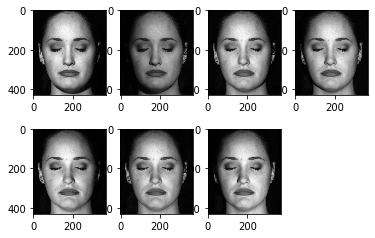

```python
ims = []
for i in range(1,8):
    ims.append(cv2.imread('./data/female_0%d.tif' % i, 0))

S = pickle.load(open('./data/sources.pickle', 'rb'))['S']

albedo = np.zeros(ims[0].shape)
normals = np.zeros((ims[0].shape[0], ims[0].shape[1], 3))

# flatten images make each of them a row
I = np.concatenate([[a.flatten()] for a in ims])

# get matrix where each row is a\vec(n), i.e. a list of 3-vectors
# which corresponds to the normal of each pixel of the image flattened
# row by row
n = np.linalg.lstsq(S, I)[0].transpose()
# norms are the albedo
a = np.sum(np.abs(n)**2,axis=-1)**(1./2)
n = n / np.concatenate([[a],[a],[a]]).transpose()

normals = n.reshape((ims[0].shape[0], ims[0].shape[1], 3))
albedo = a.reshape(ims[0].shape)

# first ill plot the images themselves, then the albedo + surface normals
for i in range(7):
    plt.subplot(240 + i + 1)
    plt.imshow(ims[i],cmap='gray')
```

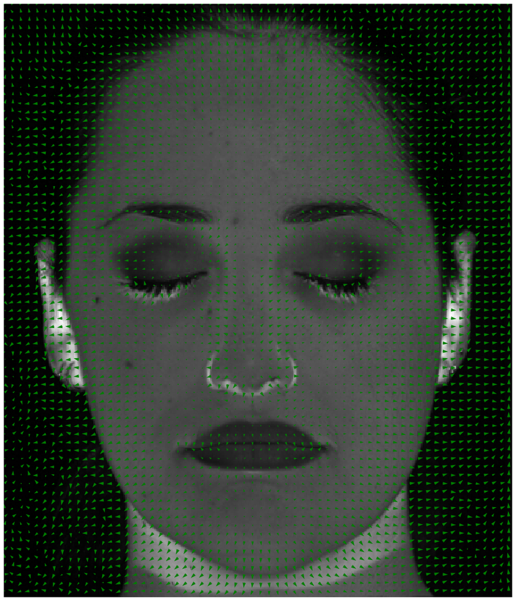

```python
plt.rcParams['figure.figsize'] = [20, 20]
plt.imshow(albedo, cmap='gray')
# invert y axis in quiver
skip = 6
plt.quiver(range(ims[0].shape[1])[::skip], range(ims[0].shape[0])[::skip],
           normals[::skip,::skip,0], normals[::skip,::skip,1],
           color='green', angles='xy')
plt.axis('image');
plt.axis('off');
```

**b.** Note the poor estimates of the albedo (and surface normal) in the area surrounding the nostrils. What is the source of this error? Describe one method for finding a better estimate of this information from these seven images.

### Answer:

This is again a problem with failing to account for occlusion! In some of the images that we used to compute the surface normals, the area near the nostrils is shadowed by the nose itself. Instead of attributing this to occlusion, the algorithm assumes this is due to surface properties and takes it into account in the computation of the normal vector, resulting in a normal vector with the wrong direction, since the shadows are not actually due to the normal direction of the surface facing away from the light but rather to that portion of the surface being covered by the nose.

Two ways to find a better estimate for the surface normals near the nostrils. We can either mask out the shadows caused by occlusion, or only use the images where there is no occlusion or comparatively less occlusion near the nostrils.

**c.** Use the recovered surface information to predict what the person would look like (in grayscale) if illuminated from direction $\hat{s}=(0.58,-0.58,-0.58)$ and from direction $\hat{s}=(-0.58,-0.58,-0.58)$. Print your results.

### Answer:

The illumination of each pixel should be given by $I = a \textbf{n}^T\vec{l}$ where $\vec{l} = (0.58, -0.58, -0.58)$ or $\vec{l} = (-0.58,-0.58,-0.58)$.

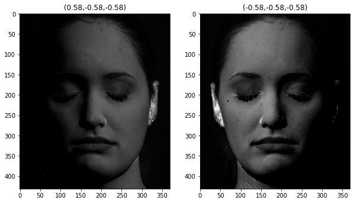

```python
plt.rcParams['figure.figsize'] = [10, 10]
l1 = np.array([0.58,-0.58,-0.58])
l2 = np.array([-0.58,-0.58,-0.58])
im1 = albedo * np.dot(normals, l1)
im2 = albedo * np.dot(normals, l2)

# account for self-shadows
im1 = np.maximum(im1, 0)
im2 = np.maximum(im2, 0)

plt.subplot(121, title='(0.58,-0.58,-0.58)')
plt.imshow(im1,cmap='gray')
plt.subplot(122, title='(-0.58,-0.58,-0.58)')
plt.imshow(im2,cmap='gray')
```

**d.** The function `integrate_frankot()` below can be used to recover a surface $z(x,y)$ from your surface normals $\hat{n}(x,y)$. Run the two cells below to generate and display your surface, and then modify the second cell to include two views of your surface.

```python
def integrate_frankot(N):

    """
    integrate_frankot(N) takes an PxQx3 field of normal vectors (the third
    dimension is [x y z]) and returns a PxQ array corresponding to the
    depth of the surface, with the mean depth equal to zero.

    Reference: Frankot, R. and Chellapa, R. (1988) "A Method for Enforcing
    Integrability in Shape from Shading Algorithms."  IEEE Trans. Pattern
    Anal. Mach. Intell. 10(4):439-451.

    Args:
        N: PxQx3 field of normal vectors

    Returns:
        PxQ array corresponding to the depth of the surface, with the mean depth equal to zero

    Todd Zickler, November 2001; updated for CS283 October. 2019.

    """

    h, w = N[:, :, 0].shape

    # complain if P or Q are too big
    if (h > 512) | (w > 512):
        print('Input array too big.  Choose a smaller window.')

    # pad the array to 512x512
    nrows = 2 ** 9
    ncols = 2 ** 9

    # get surface slopes from normals; ignore points where normal is [0 0 0]
    x_sample = 1
    y_sample = 1
    zx = -x_sample * (np.sum(N, 2) != 0) * N[:, :, 0] / (N[:, :, 2] + (N[:, :, 2] == 0))
    zy = -y_sample * (np.sum(N, 2) != 0) * N[:, :, 1] / (N[:, :, 2] + (N[:, :, 2] == 0))

    Zx_sq = np.fft.fft2(zx, s=[nrows, ncols])
    Zy_sq = np.fft.fft2(zy, s=[nrows, ncols])
    h2 = nrows
    w2 = ncols

    Zx = Zx_sq.flatten('C')
    Zy = Zy_sq.flatten('C')

    # compute repeated frequency vectors (See Chellapa paper)
    h2_vec = np.expand_dims(np.concatenate((np.arange(0, h2/2 + 1),np.arange(-h2/2+1, 0))), 1)
    w2_vec = np.expand_dims(np.concatenate((np.arange(0, w2/2 + 1),np.arange(-w2/2+1, 0))), 1)

    Wx = np.squeeze(np.tile(2 * np.pi / h2 * h2_vec, [w2, 1]))
    Wy = np.squeeze(np.kron(2 * np.pi / w2 * w2_vec, np.ones((h2, 1))))

    # compute transform of least squares closest integrable surface
    Wx[0] = 1
    Wy[0] = 1
    # remove first column because it's all zeros (then add C(0)=0)
    C = (-1j * Wx * Zx - 1j * Wy * Zy) / (np.power(Wx, 2) + np.power(Wy, 2))

    # set DC component of C
    C[0] = 0

    # invert transform to get depth of integrable surface
    Z = np.real(np.fft.ifft2(np.reshape(C, [h2, w2], 'C')))

    # crop Z to original input shape
    Z = Z[:h, :w]

    return Z
```

```python
n = normals
```

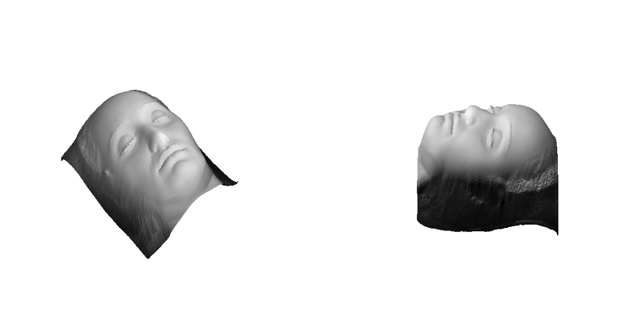

```python
# Run the cell below to plot Z as a surface:

Z = integrate_frankot(n)

h, w = n[:, :, 0].shape

# Define a meshgrid of X and Y coordinates
X,Y = np.meshgrid(np.arange(w), np.arange(h))

# Create a figure and define its axes
fig = plt.figure(figsize=(20,10))
ax = fig.add_subplot(1,2,1,projection='3d')
ax.axis('off')

# Define the viewing angle
ax.view_init(elev=240, azim=-50)

# Define a light source direction
ls = LightSource(azdeg=260, altdeg=125)
surf_illum = ls.shade(Z, cmap=cm.gist_yarg)

# Shade data, creating an rgb array.
surf = ax.plot_surface(X, Y, Z, rstride=2, cstride=2, linewidth=0,
                       antialiased=False, facecolors=surf_illum)#color='gray')
# Resolution of rendering and time needed to render will depend on rstride and cstride

# Create cubic bounding box to simulate equal aspect ratio
# https://stackoverflow.com/questions/13685386/matplotlib-equal-unit-length-with-equal-aspect-ratio-z-axis-is-not-equal-to
max_range = np.array([X.max()-X.min(), Y.max()-Y.min(), Z.max()-Z.min()]).max()
Xb = 0.5*max_range*np.mgrid[-1:2:2,-1:2:2,-1:2:2][0].flatten() + 0.5*(X.max()+X.min())
Yb = 0.5*max_range*np.mgrid[-1:2:2,-1:2:2,-1:2:2][1].flatten() + 0.5*(Y.max()+Y.min())
Zb = 0.5*max_range*np.mgrid[-1:2:2,-1:2:2,-1:2:2][2].flatten() + 0.5*(Z.max()+Z.min())
# Comment or uncomment following both lines to test the fake bounding box:
for xb, yb, zb in zip(Xb, Yb, Zb):
    ax.plot([xb], [yb], [zb], 'w')

# Second subplot
ax = fig.add_subplot(1,2,2,projection='3d')
ax.axis('off')

# Define the viewing angle
ax.view_init(elev=320, azim=0)

# Define a light source direction
ls = LightSource(azdeg=250, altdeg=125)
surf_illum = ls.shade(Z, cmap=cm.gist_yarg)

# Shade data, creating an rgb array.
surf = ax.plot_surface(X, Y, Z, rstride=2, cstride=2, linewidth=0,
                       antialiased=False, facecolors=surf_illum)#color='gray')
# Resolution of rendering and time needed to render will depend on rstride and cstride

# Create cubic bounding box to simulate equal aspect ratio
# https://stackoverflow.com/questions/13685386/matplotlib-equal-unit-length-with-equal-aspect-ratio-z-axis-is-not-equal-to
max_range = np.array([X.max()-X.min(), Y.max()-Y.min(), Z.max()-Z.min()]).max()
Xb = 0.5*max_range*np.mgrid[-1:2:2,-1:2:2,-1:2:2][0].flatten() + 0.5*(X.max()+X.min())
Yb = 0.5*max_range*np.mgrid[-1:2:2,-1:2:2,-1:2:2][1].flatten() + 0.5*(Y.max()+Y.min())
Zb = 0.5*max_range*np.mgrid[-1:2:2,-1:2:2,-1:2:2][2].flatten() + 0.5*(Z.max()+Z.min())
# Comment or uncomment following both lines to test the fake bounding box:
for xb, yb, zb in zip(Xb, Yb, Zb):
    ax.plot([xb], [yb], [zb], 'w')

# Show the plot
plt.show()
```

## Hints and Information

- The following code demonstrates one way to use the `matplotlib.pyplot.quiver` function.

```
# vect_x is an HxW array of x-components
# vect_y is an HxW array of y-components
plt.figure()
plt.quiver(vect_x,vect_y,cmap='gray')
plt.gca().invert_yaxis();
plt.axis('image');
plt.axis('off')';
```

Note that the vector components should be displayed at a suitable resolution. For example, the figure below shows the $x$-$y$ components of a field of surface normals at three different resolutions. The plot in the middle provides the best summary of the surface shape. The resolution can be adjusted by plotting only every $n^\mathrm{th}$ element as in `plt.quiver(vect_x[::n, ::n], vect_y[::n, ::n])`.

[figure not shown]

- When computing the output radiance from a field of surface normals $\hat{n}(x,y)$ illuminated from direction $\hat{s}$, clip negative values using $L=\max(0,\hat{n}\cdot\hat{s})$.
- We are commonly faced with a situation in which we need to evaluate the integral over the hemisphere of the function $\cos\theta$, where $0\le\theta\pi$ is the angular distance between the radial line through a point on the hemisphere and the radial line through its apex.

\begin{equation} \int_\Omega \cos\theta d\omega \end{equation}

The first step is to define a parameterization of the hemisphere using spherical coordinates, and the second is to write an element of the solid angle $d\omega$ in terms of this parameterization. As shown in almost any introductory calculus book (and Forsyth & Ponce), we can write this integral as

\begin{equation} \int_0^{2\pi} \int_0^{\pi/2} \cos\theta\sin\theta d\theta d\phi, \end{equation}

which is straightforward to evaluate using the appropriate trigonometric identity.